# Signal Subgraphing for Batch Effect Detection

Eric Bridgeford

November 29, 2017

```r
# load packages
#==========================#
require(fmriutils)
require(VCA)
require(stringr)
require(lme4)
require(RColorBrewer)
require(oro.nifti)
require(reshape2)
require(latex2exp)
require(ggplot2)
require(Rmisc)
require(subgraphing)

# functions
#==========================#

xscale.log2 <- function(a=3, b=6, n=10) {
  return(round(2^(seq(a, b, length.out=n))))
}

xscale.log10 <- function(a=1, b=3, n=10) {
  return(round(10^(seq(a, b, length.out=n))))
}

# accepts a matrix and thresholds/binarizes it
thresh_matrix = function(matrix, thresh=0.5) {
  thr = quantile(matrix, thresh)
  return(ifelse(matrix > thr, 1, 0))
}
```

# Setting

## Task

Given:

- $\mathbb{G}: \Omega \rightarrow \mathcal{G}$ is a graph-valued RV with samples $G_i \sim \mathbb{G}$.
- For each $G_i \in \mathcal{G}$, we have $G_i = (V, E_i)$; that is, each $G_i$ is defined by a set of vertices $V$ and a set of edges $E_i$, where $w_i: V \times V \rightarrow \{0, 1\}$, and $w_i(e_{uv}) \in \{0, 1\}$. That is, each graph has binary edges.
- We have a collection of classes $\mathcal{Y}$ where the collection of graphs in class $y_i$ have a class-conditional difference with the collection of graphs in class $y_j$ for $i \neq j$ comprising the signal present in the graphs.
- $\mathbb{A}_{y, z}: \Omega \rightarrow \mathcal{A}_{y, z}$, an adjacency-matrix-valued RV with samples $A_{i | y_i = y, z_i = z} \sim \mathbb{A}_{y, z}$, where $\mathcal{A}_{y, z}$ is the space of possible adjacency-matrices and $A_{i | y_i = y, z} \in \mathcal{A}_y$.
- $A_{i | y_i = y, z_i = z} \in \mathcal{A}_{y, z}$, and $\mathcal{A}_{y, z} \subseteq \mathbb{R}^{V \times V}$.
- Each graph $G_i$ can be represented as an adjacency-matrix $A_i$.
- Within each graph, there exists some collection of edges $\mathcal{S}$ called the subgraph that contain the bulk of the class differences between the $y$s.
- Class labels $z_i \in Z$, where $Z$ is a set of variables that will contribute random noise to our observations. This will be referred to as the batch-effect.

Characterize the composition of signal to batch-effect present in the given connectomes, assuming both the fixed-effects and random-effects can be characterized as random inputs in a standard mixed-effects model.

## Model

Assume that the edge weights can be characterized by a bernoulli RV; that is:

$$\begin{align}
\mathbb{A}_{uv | y, z} \sim Bern(p_{uv| y, z})
\end{align}$$

where $p_{uv| y, z}$ is the probability of edge $e_{uv}$ being connected for $y, z$.

Then our likelihood function is simply:

$$\begin{align}
L_{\mathbb{A}}(A_i; \theta) &= \prod_{(u, v) \in E_i} Bern(w_i(e_{uv}); p_{uv}) \\
&= \prod_{(u, v) \in E_i} p_{uv}^{w_i(e_{uv})}(1 - p_{uv})^{1 - w_i(e_{uv})}
\end{align}$$

# Estimators

## Bernoulli Parameters

Using MLE, it is easy to see that:

$$\begin{align}
\hat{p}_{uv} = \frac{1}{n} \sum_{i=1}^n w_i(e_{uv})
\end{align}$$

where $w_i(e_{uv}) \in \{0, 1\}$ is the binary edge weight of edge $e_{uv}$.

Note that if $w_i(e_{uv}) = 0 \;\forall i$, then $p_{uv} = 0$, which is undesirable since we only have a finite sample (and successive samples where $w_i(e_{uv})) \neq 0$ would lead to poor model performance), and vice versa for $p_{uv} = 1$ when $w_i(e_{uv}) = 0 \;\forall i$. Then consider the smoothed estimator:

$$\begin{align}
p_{uv} = \begin{cases}
n_n & max_{i}(w_i(e_{uv})) = 0 \\
1-n_n & max_{i}(w_i(e_{uv})) = 1 \\
p_{uv} & else
\end{cases}
\end{align}$$

## Priors

Here, we take the maximum likelihood estimators for the prior probabilities, which assuming our data is sampled iid from our population, should suffice:

$$\begin{align}
\hat{\pi}_y = \frac{n_y}{n}
\end{align}$$

where $n_y = \sum_{i =1}^n \mathbb{I}\{y_i = y\}$.

## Incoherent Subgraph

### Test

- [Fisher’s Exact Test](https://en.wikipedia.org/wiki/Fisher%27s_exact_test): Given the following contingency table:

| Edge | Class 1 | Class 2 |
| --- | --- | --- |
| Present | a | b |
| Not Present | c | d |

where $a=n_{uv | y = 1}$, $b=n_{uv | y = 2}$, $c=n_{y = 1} - n_{uv | y = 1}$, $d=n_{y = 1} - n_{uv | y = 1}$.

we can test whether the differences of proportions we identify is significant with the following test:

$$\begin{align*}
H_0: \textrm{the difference of proportions is insigificant} \\
H_A: \textrm{the difference of proportions is significant}
\end{align*}$$

Assuming the contingency table follows the [hypergeometric distribution](https://en.wikipedia.org/wiki/Hypergeometric_distribution), we can formulate the following test-statistic:

$$\begin{align*}
\mathcal{T}_{fisher, uv} = \frac{\begin{pmatrix}n_{uv} \\ a_{uv} + b_{uv}\end{pmatrix}\begin{pmatrix}c_{uv} + d_{uv} \\ c_{uv}\end{pmatrix}}{\begin{pmatrix}n_{uv} \\ a_{uv} + c_{uv}\end{pmatrix}}
\end{align*}$$

where $n = a_{uv} + b_{uv} + c_{uv} + d_{uv}$.

### P-value

We can compute a p-value of falsely rejecting the null hypothesis by simply finding the area:

$$\begin{align*}
p = \int_{-\mathcal{T}_{observed}}^{\infty}p(x) dx = 1 - \int_{-\infty}^{\mathcal{T}_{observed}} p(x)dx
\end{align*}$$

Fisher has shown that the probability of obtaining any such set of values is exactly the test-statistic, so $p = \mathcal{T}_{observed}$.

### Power

The statistical power can be computed as the inverse of the probability of making a Type II ($\beta$) error, $1 - \beta$. A type II error can be defined as follows:

$$\begin{align*}
\beta = \mathbb{P}(\textrm{reject $H_A$ in favor of $H_0$ | $H_A$ is true}) = \mathbb{P}(\mathcal{T}_{observed} < \mathcal{T}_{critical})
\end{align*}$$

In this case, $\mathcal{T}_{critical} = \alpha$, and $\mathcal{T}_{observed} = p$. We can formulate synthetic testing power using a post-hoc test.

## pseudo-code

To estimate the incoherent subgraph, we consider the following algorithm:

incoherent_subgraph(G, e):

- assemble a contingency matrix, per edge, counting the number of occurences of a graph from each class having or not having a connection.
- compute the p-value of Fisher’s exact test on the contingency matrix for each edge to produce the test statistic $\mathcal{T}_{uv}$. The $p$ value signifies the probability of the null hypothesis, that there is no class-conditional difference present for edge $uv$, versus the alternative that there is a class-conditional difference present for edge $uv$.
- order the test statistics in increasing order, such that $\mathcal{T}^{(1)}_{uv} \leq \mathcal{T}^{(2)}_{u'v'} \leq ...$ for all the edges.
- choose the first $e$ edges as estimator of the signal-subgraph $\hat{\mathcal{S}}$.

# Real Data

```r
sig = 0.01  # global param for significance threshold
```

## Diffusion

```r
nroi = 70
atlases = c("desikan")
dwi.dsets = c('BNU1', 'BNU3', 'HNU1', 'KKI2009', 'Templeton114', 'SWU4')

graphobj <- fmriu.io.collection.open_graphs(basepath='/data/dwi/edgelists/', datasets = dwi.dsets,
                                            atlases = atlases, gname = "graphs", fmt='edgelist', rtype='array')
```

```
## [1] "opening graphs for BNU1 dataset and desikan parcellation atlas..."
## [1] "opening graphs for BNU3 dataset and desikan parcellation atlas..."
## [1] "opening graphs for HNU1 dataset and desikan parcellation atlas..."
## [1] "opening graphs for KKI2009 dataset and desikan parcellation atlas..."
## [1] "opening graphs for Templeton114 dataset and desikan parcellation atlas..."
## [1] "opening graphs for SWU4 dataset and desikan parcellation atlas..."
```

```r
graphs = graphobj$graphs
```

```r
gcpy = graphs
datasets = graphobj$dataset
subjects = graphobj$subjects
sessions = graphobj$sessions

parse_class <- function(basepath, dsets, subjects) {
  sex = list()
  # disease = list()
  age = list()
  include = c()
  for (dset in dsets) {
    path_to_file = file.path(basepath, paste(dset, "_phenotypic_data.csv", sep=""))
    tab = read.csv(path_to_file)
    tab$SEX[tab$SEX == '#' | is.na(tab$SEX) | is.nan(tab$SEX)] = NaN
    if (dset == 'KKI2009') {
      sexm <- 'M'
    } else if (dset == 'Templeton114') {
      sexm <- 1
    } else {
      sexm <- 2
    }
    tab$AGE_AT_SCAN_1 <- factor(tab$AGE_AT_SCAN_1)
    tab$SEX = tab$SEX == sexm
    tab = tab[complete.cases(tab$SEX),]
    tab$AGE_AT_SCAN_1 = as.numeric(levels(tab$AGE_AT_SCAN_1))[tab$AGE_AT_SCAN_1]
    for (idx in 1:dim(tab)[1]) {
      subid = toString(tab[idx,]$SUBID)
      sex[[subid]] = tab[idx,]$SEX
      age[[subid]] = tab[idx,]$AGE_AT_SCAN_1
      # disease[[subid]] = tab[idx,]$DSM_IV_TR
    }
  }

  sclass = array(NaN, dim=c(length(subjects)))
  ageclass = sclass
  # diseaseclass = sclass
  for (i in 1:length(subjects)) {
    subject = subjects[i]
    subid = sub('^0+(?=[1-9])', '', str_extract(subject, '(?<=sub-).*'), perl=TRUE)
    idx = which(names(sex) == subid)
    if (length(idx) >= 1) {
      sclass[i] <- sex[[subid]]
      ageclass[i] <- age[[subid]]
      # diseaseclass[i] <- disease[[subid]]
    }
  }
  return(list(sex=sclass, age=ageclass))#, disease=diseaseclass))
}

sexpath = '/home/eric/Documents/research/mgc-repos/fmribatch_notes/data/phenotypic_data/'
class = parse_class(sexpath, dwi.dsets, subjects)
sexs = class$sex
# dwi.diseases = class$disease
ages = class$age

dwi.graphs = graphs[!is.nan(ages) & !is.nan(sexs),,]
dwi.datasets = datasets[!is.nan(ages) & !is.nan(sexs)]
dwi.subjects = subjects[!is.nan(ages) & !is.nan(sexs)]
dwi.sessions = sessions[!is.nan(ages) & !is.nan(sexs)]
dwi.ages = ages[!is.nan(ages) & !is.nan(sexs)]
dwi.sexs = sexs[!is.nan(ages) & !is.nan(sexs)]
```

```r
dwi.bin_graphs = apply(dwi.graphs, c(2,3), function(x) thresh_matrix(x, thresh=0))
dwi.bin_graphs <- aperm(dwi.bin_graphs, c(2,3,1))
nds = length(dwi.dsets)


dwi.dset.ssgs <- array(0, dim=c(nroi, nroi, nds))  # save the ssgs per dataset
for (i in 1:nds) {
  ss = dwi.datasets == dwi.dsets[i]
  subset.gr = dwi.bin_graphs[,,ss]
  subset.sex = dwi.sexs[ss]
  sg_ests <- sg.bern.subgraph_estimator(subset.gr, subset.sex)
  # compute test statistics per edge from the contingency matrix
  tstats <- sg.bern.edge_test(sg_ests$cont_matrix)
  dwi.dset.ssgs[,,i] = 1*(tstats < sig)
}

sg_ests <- sg.bern.subgraph_estimator(dwi.bin_graphs, dwi.sexs)
# compute test statistics per edge from the contingency matrix
tstats <- sg.bern.edge_test(sg_ests$cont_matrix)
dwi.global.ssg <- 1*(tstats < sig)
```

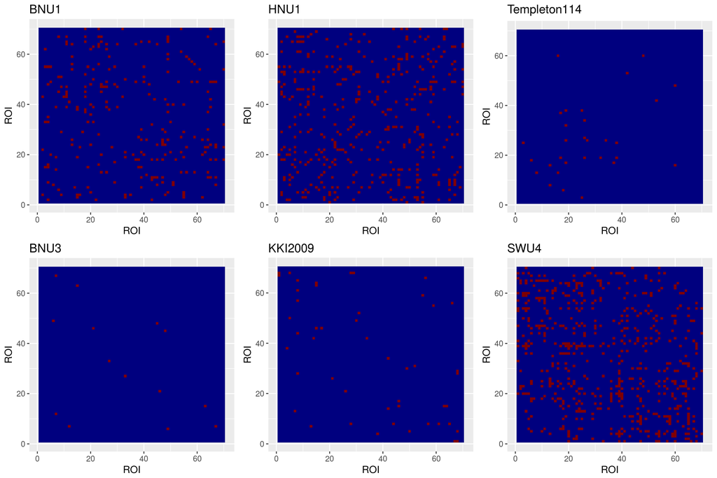

```r
dset_plots <- list()

counter <- 1
for (i in 1:length(dwi.dsets)) {
  dset_plots[[counter]] <- fmriu.plot.plot_graph(dwi.dset.ssgs[,,i],  legend.name=TeX("$I_{uv}$"),
                      title=dwi.dsets[i],
                      limits=c(min(dwi.dset.ssgs), max(dwi.dset.ssgs)), xlabel = "ROI",
                      ylabel = "ROI") + theme(legend.position=NaN)
  counter <- counter + 1
}

multiplot(plotlist = dset_plots, cols = ceiling(sqrt(length(dwi.dsets))))
```

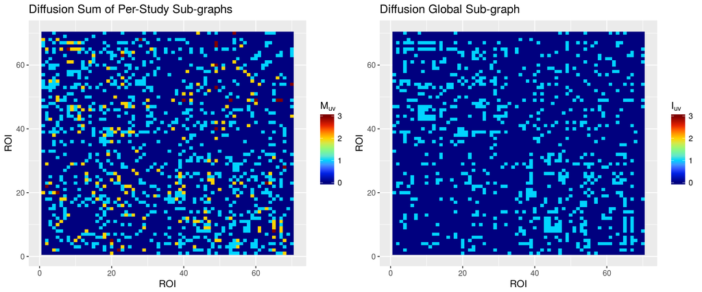

```r
local_ssg <- apply(dwi.dset.ssgs, c(1,2), sum)
plots <- list()
plots[[1]] <- fmriu.plot.plot_graph(local_ssg,  legend.name=TeX("$M_{uv}"),
                      title="Diffusion Sum of Per-Study Sub-graphs",
                      limits=c(min(local_ssg), max(local_ssg)), xlabel = "ROI",
                      ylabel = "ROI")
plots[[2]] <- fmriu.plot.plot_graph(dwi.global.ssg,  legend.name=TeX("$I_{uv}$"),
                      title="Diffusion Global Sub-graph",
                      limits=c(min(local_ssg), max(local_ssg)), xlabel = "ROI",
                      ylabel = "ROI")
multiplot(plotlist=plots, cols = 2)
```

as we can see, oddities in the sub-graphs seem somewhat consistent in the per-study vs the global sub-graph.

### Functional

```r
nroi = 70
atlases = c('desikan-2mm')

fmri.dsets = c('BNU1', 'BNU2', 'BNU3', 'HNU1', 'IBATRT', 'IPCAS1', 'IPCAS2', 'IPCAS8',
               'NYU1', 'SWU1', 'SWU2', 'SWU3', 'SWU4', 'UWM', 'XHCUMS')

graphobj <- fmriu.io.collection.open_graphs(basepath='/data/fmri/raw/edgelists/', datasets = fmri.dsets,
                                            atlases = atlases, fmt='edgelist', rtype='array')
```

```
## [1] "opening graphs for BNU1 dataset and desikan-2mm parcellation atlas..."
## [1] "opening graphs for BNU2 dataset and desikan-2mm parcellation atlas..."
## [1] "opening graphs for BNU3 dataset and desikan-2mm parcellation atlas..."
## [1] "opening graphs for HNU1 dataset and desikan-2mm parcellation atlas..."
## [1] "opening graphs for IBATRT dataset and desikan-2mm parcellation atlas..."
## [1] "opening graphs for IPCAS1 dataset and desikan-2mm parcellation atlas..."
## [1] "opening graphs for IPCAS2 dataset and desikan-2mm parcellation atlas..."
## [1] "opening graphs for IPCAS8 dataset and desikan-2mm parcellation atlas..."
## [1] "opening graphs for NYU1 dataset and desikan-2mm parcellation atlas..."
## [1] "opening graphs for SWU1 dataset and desikan-2mm parcellation atlas..."
## [1] "opening graphs for SWU2 dataset and desikan-2mm parcellation atlas..."
## [1] "opening graphs for SWU3 dataset and desikan-2mm parcellation atlas..."
## [1] "opening graphs for SWU4 dataset and desikan-2mm parcellation atlas..."
## [1] "opening graphs for UWM dataset and desikan-2mm parcellation atlas..."
## [1] "opening graphs for XHCUMS dataset and desikan-2mm parcellation atlas..."
```

```r
graphs = graphobj$graphs
```

```r
gcpy = graphs
datasets = graphobj$dataset
subjects = graphobj$subjects
sessions = graphobj$sessions

parse_class <- function(basepath, dsets, subjects) {
  sex = list()
  # disease = list()
  age = list()
  include = c()
  for (dset in dsets) {
    path_to_file = file.path(basepath, paste(dset, "_phenotypic_data.csv", sep=""))
    tab = read.csv(path_to_file)
    tab$SEX[tab$SEX == '#' | is.na(tab$SEX) | is.nan(tab$SEX)] = NaN
    if (dset == 'KKI2009') {
      sexm <- 'M'
    } else if (dset == 'Templeton114') {
      sexm <- 1
    } else {
      sexm <- 2
    }
    tab$AGE_AT_SCAN_1 <- factor(tab$AGE_AT_SCAN_1)
    tab$SEX = tab$SEX == sexm
    tab = tab[complete.cases(tab$SEX),]
    tab$AGE_AT_SCAN_1 = as.numeric(levels(tab$AGE_AT_SCAN_1))[tab$AGE_AT_SCAN_1]
    for (idx in 1:dim(tab)[1]) {
      subid = toString(tab[idx,]$SUBID)
      sex[[subid]] = tab[idx,]$SEX
      age[[subid]] = tab[idx,]$AGE_AT_SCAN_1
      # disease[[subid]] = tab[idx,]$DSM_IV_TR
    }
  }

  sclass = array(NaN, dim=c(length(subjects)))
  ageclass = sclass
  # diseaseclass = sclass
  for (i in 1:length(subjects)) {
    subject = subjects[i]
    subid = sub('^0+(?=[1-9])', '', str_extract(subject, '(?<=sub-).*'), perl=TRUE)
    idx = which(names(sex) == subid)
    if (length(idx) >= 1) {
      sclass[i] <- sex[[subid]]
      ageclass[i] <- age[[subid]]
      # diseaseclass[i] <- disease[[subid]]
    }
  }
  return(list(sex=sclass, age=ageclass))#, disease=diseaseclass))
}

sexpath = '/home/eric/Documents/research/mgc-repos/fmribatch_notes/data/phenotypic_data/'
class = parse_class(sexpath, fmri.dsets, subjects)
sexs = class$sex
# dwi.diseases = class$disease
ages = class$age

fmri.graphs = graphs[!is.nan(ages) & !is.nan(sexs),,]
fmri.datasets = datasets[!is.nan(ages) & !is.nan(sexs)]
fmri.subjects = subjects[!is.nan(ages) & !is.nan(sexs)]
fmri.sessions = sessions[!is.nan(ages) & !is.nan(sexs)]
fmri.ages = ages[!is.nan(ages) & !is.nan(sexs)]
fmri.sexs = sexs[!is.nan(ages) & !is.nan(sexs)]
```

```r
fmri.bin_graphs = apply(fmri.graphs, c(2,3), function(x) thresh_matrix(x, thresh=0.5))
fmri.bin_graphs <- aperm(fmri.bin_graphs, c(2,3,1))
nds = length(fmri.dsets)

fmri.dset.ssgs <- array(0, dim=c(nroi, nroi, nds))  # save the ssgs per dataset
for (i in 1:nds) {
  ss = fmri.datasets == fmri.dsets[i]
  subset.gr = fmri.bin_graphs[,,ss]
  subset.sex = fmri.sexs[ss]
  sg_ests <- sg.bern.subgraph_estimator(subset.gr, subset.sex)
  # compute test statistics per edge from the contingency matrix
  tstats <- sg.bern.edge_test(sg_ests$cont_matrix)
  fmri.dset.ssgs[,,i] = 1*(tstats < sig)
}

sg_ests <- sg.bern.subgraph_estimator(fmri.bin_graphs, fmri.sexs)
# compute test statistics per edge from the contingency matrix
tstats <- sg.bern.edge_test(sg_ests$cont_matrix)
fmri.global.ssg <- 1*(tstats < sig)
```

and also, the local and globally estimated sub-graph with edges $I_{uv} = \mathbb{I}\{(u, v) \in \mathcal{S}\}$. Assuming the batch-effect is small, we intuitively expect that the two should look relatively similar:

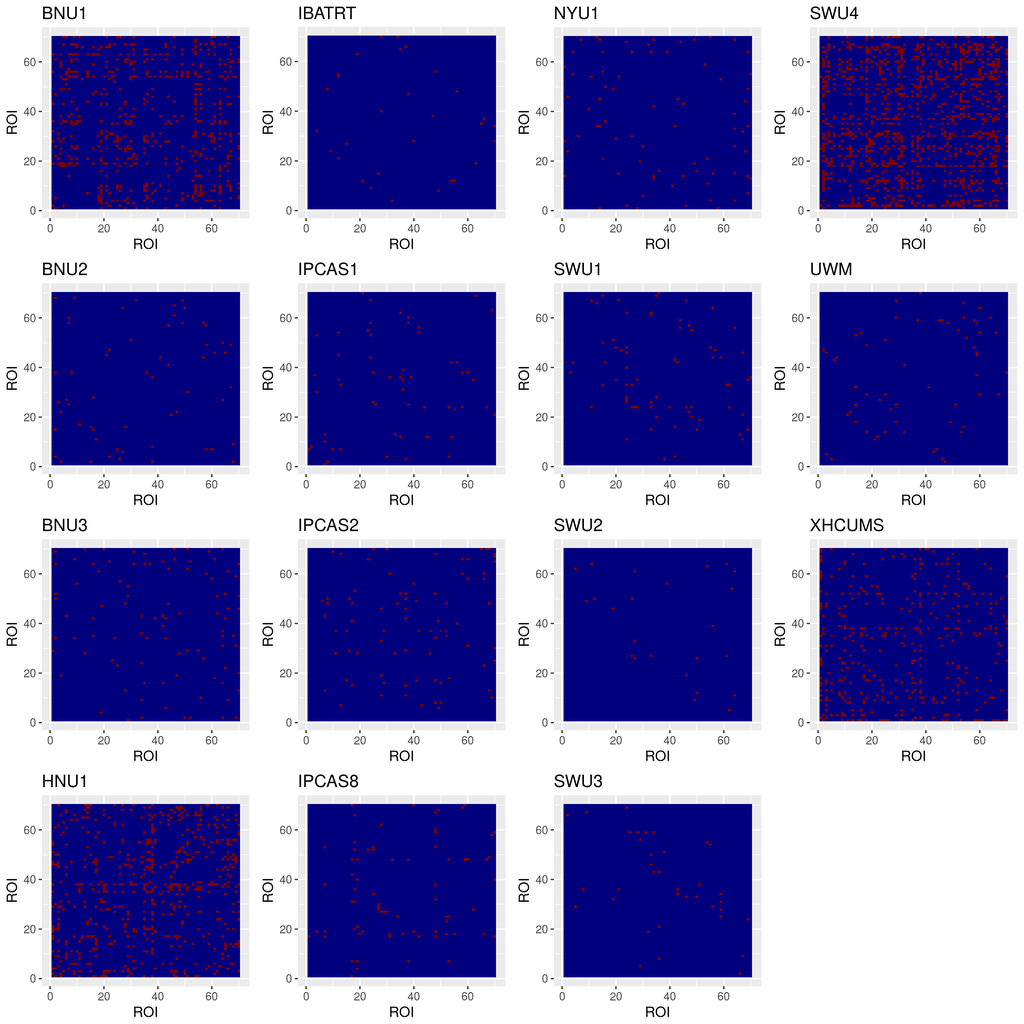

```r
dset_plots <- list()

counter <- 1
for (i in 1:length(fmri.dsets)) {
  dset_plots[[counter]] <- fmriu.plot.plot_graph(fmri.dset.ssgs[,,i],  legend.name=TeX("$I_{uv}$"),
                      title=fmri.dsets[i],
                      limits=c(min(fmri.global.ssg), max(fmri.global.ssg)), xlabel = "ROI",
                      ylabel = "ROI") + theme(legend.position=NaN)
  counter <- counter + 1
}

multiplot(plotlist = dset_plots, cols = round(sqrt(length(fmri.dsets))))
```

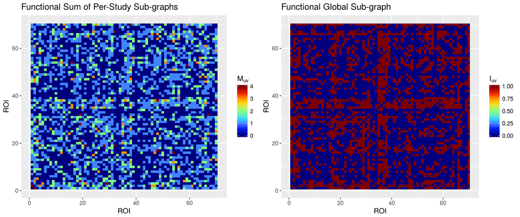

```r
local_ssg <- apply(fmri.dset.ssgs, c(1,2), sum)

plots <- list()
plots[[1]] <- fmriu.plot.plot_graph(local_ssg,  legend.name=TeX("$M_{uv}"),
                      title="Functional Sum of Per-Study Sub-graphs",
                      limits=c(min(local_ssg), max(local_ssg)), xlabel = "ROI",
                      ylabel = "ROI")
plots[[2]] <- fmriu.plot.plot_graph(fmri.global.ssg,  legend.name=TeX("$I_{uv}$"),
                      title="Functional Global Sub-graph",
                      limits=c(min(fmri.global.ssg), max(fmri.global.ssg)), xlabel = "ROI",
                      ylabel = "ROI")
multiplot(plotlist=plots, cols = 2)
```